# Final Paper

STOR 320/520.405 Group 12

December 03, 2022

# INTRODUCTION

The first impression a person gives to a potential romantic partner is increasingly important in whether they will date you in the future. Therefore, Speed dating receives popularities recently. Speed dating is for people to meet new people in a friendly and relaxing environment, and ideally, they have opportunities to organize a future date if two people like each other. Typically, participants will be asked to rate their dates based on six primary attributes: Attractiveness, Sincerity, Intelligence, Fun, Ambition, and Shared Interests.

Given that these factors contributed to the potential success of finding a dating partner, our initial interest is to find what factors are most important in determining a potentially ideal partner to date. The dataset for our analysis was compiled by Columbia Business School professors Ray Fisman and Sheena Iyengar for their paper Gender Differences in Mate Selection: Evidence From a Speed Dating Experiment. It collects over 500 people aged 18–55 who participated in the experimental speed dating events from 2002–2004. As the dataset also examines gender differences in finding a dating partner, we want to further find important factors leading a specific gender to be willing to date the matched partner in the future.

Therefore, our first question is **“Can we predict if a woman will ask for another date with her matched man in Speed Dating Events?”**. Although this dataset does not give a specific variable to indicate that females would date their matched males, we assume that in variable, likely_date, scores above 7 mean that women are willing to have another date with matched partners. By selecting attributes rated by women with numerical values, we hope to find whether women would ask for a further date based on selected attributes.

Our second question is **“Can we predict the result of matches based on the personal information of participants?”** Since this dataset includes background information like career and income, we hope to find the importance of personal information in determining the result of matches after participants’ meetings.

# DATA

As mentioned before, Professors Ray Fisman and Sheena Iyengar of Columbia Business School created the Speed Dating dataset, which was originally used for the study *“Gender Differences in Mate Selection: Evidence from a Speed Dating Experiment”*. To be more specific, from 2002 to 2004, more than 500 people between the ages of 18 and 55 attended the experimental speed dating sessions. Individuals had a four-minute “first date” with participants of the opposite sex during the events. Participants evaluated each date based on some attributes, such as *attractiveness*, *sincerity*, *intelligence*, *fun*, *ambition*, and *shared interests*. The dataset also contains information from other questionnaires about the participants, such as demographics, dating habits, self-perceptions of important characteristics, opinions about what other people value in a partner, and lifestyle details.

For our analysis, the variables that we used here are numerical data. Those data are the ranking that the female has on the males. Some of the data is filled out by the females after meeting their matched men. The reason that we use the numerical data is that it would be easier for us to do the prediction for the *likely_date*. *likely_date* shows the females’ willingness to go on the next date. The *likely_date* here is a binary variable, with 1 meaning they are likely to have the next date with the males, with 0 meaning they are unlikely to have the next date with the males. Then we use the correlation function to obtain the top eight features that have the strongest correlation with the *likely_date* As with their strongest correlation with the likely date, the top eight features are more helpful in predicting the *likely_date* In this way, it can improve the reliability of our prediction model. The top eight features are *fun*, *share*, *intelligent*, *sincere*, *ambitious*, *expect a happy level before the event*, *music*, and *race*. Here, *fun*, *share*, *intelligent*, *sincere* and *ambitious* are the variables that the females rank from 1-10. The ranking number shows how they feel about the matched males regard to these variables. The *shared variable* shows that they have shared interests. This score of this variable is filled out by the females. The score shows if they have many shared interests with men or not. The *music* is a variable that indicates the females’ interest level in the music, on a scale of 1-10. The *race* is indicated by 1-6, with each number representing a different race. This is to identify the race of the females and males.

In addition to those eight features discussed above, we also include the other variables. In detail, they are *art concerts*, *museums*, *hiking*, *goal*, *go_out*, *exercise*, *reading*, *age*, *date*, *gaming*, *movies*, *yoga*, *int_corr*, *dining*, *tvsports*, *shopping*, *tv*, *theater*, *imprace*, *imprelig*, *income*, *clubbing.* To explain, the variables: *art concerts*, *museums*, *hiking*, *exercise*, *reading*, *gaming*, *movies*, *yoga*, *dining*, *tvsports*, *shopping*, *tv*, *theater*, and *clubbing*; these are the variables that the females rated from 1-10, indicating how interested they are in these activities. *Go_out* shows the frequency that they go out, on a scale of 1-7; with “Several times a week” ranking at 1 to “Almost never” ranking at 7. *Date* shows the frequency with that they go on dates. *Age* shows the age of the participating females. *Goal* shows their primary goal in participating in the event; with “Seemed like a fun night out” rate at 1 to “To say I did it rate at 5”. *Int_corr* is the correlation between the participant’s and partner’s ratings of interests the first time that they meet. *Imprace* and *imprelig* are similar variables, indicating the importance of the same race or background and the importance of the same religious background. *Income* is the Median household income based on zip code using the Census Bureau website. And when the income appears to be blank, it means that they are either from abroad or did not enter their zip code.

To obtain a basic understanding of the goal for people participating in the speed-dating event, we created a plot below to show the distribution of different purposes. The plot shows that most people (roughly 3400 people) think speed-dating is an interesting activity, and the second most people (around 3000 people) consider speed-dating events as a way to meet new people.

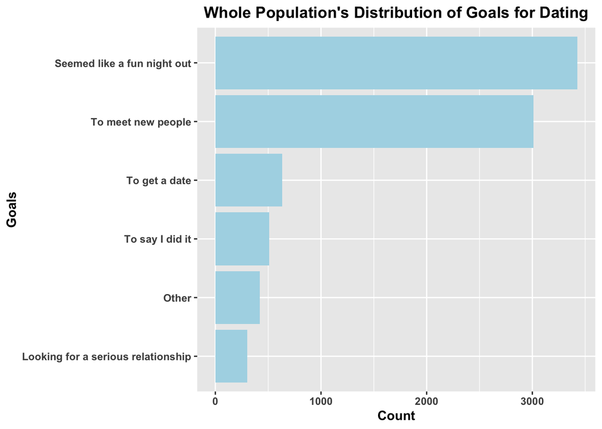

We also include which race is mostly interested in speed-dating activity, and the resulting plot is below. It shows that Europeans like speed dating most (with around 4600 people). Asians rank second place in speed-dating, but interestingly, the number of Asians loving speed-dating is around 2000, which is far less than the number of Europeans.

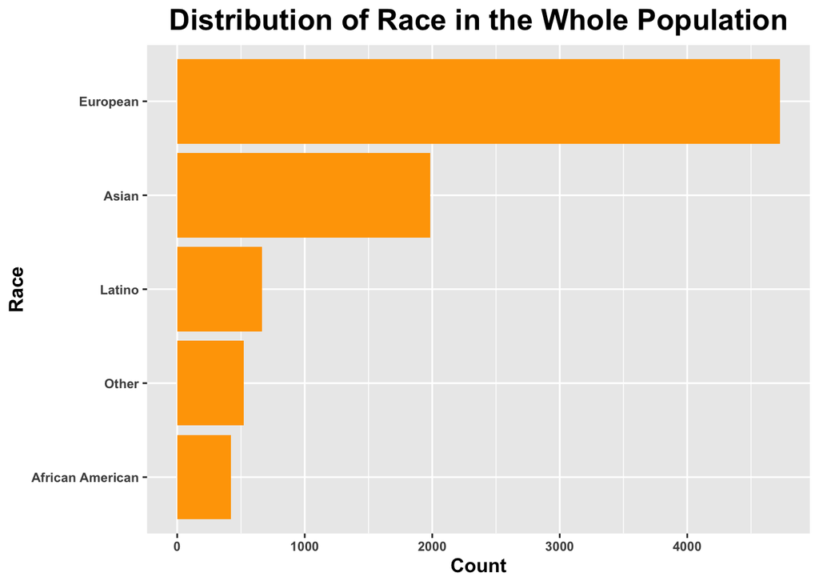

To briefly show all variables we choose, We create a summary also shown below. For the purpose of simplicity, we just include the first 10 observations and some variables may not be displayed.

| likely_date | int_corr | age | race | imprace | imprelig | income | goal | date | go_out |
| --- | --- | --- | --- | --- | --- | --- | --- | --- | --- |
| 1 | 0.14 | 21 | 4 | 2 | 4 | 69487 | 2 | 7 | 1 |
| 1 | 0.54 | 21 | 4 | 2 | 4 | 69487 | 2 | 7 | 1 |
| 1 | 0.16 | 21 | 4 | 2 | 4 | 69487 | 2 | 7 | 1 |
| 1 | 0.61 | 21 | 4 | 2 | 4 | 69487 | 2 | 7 | 1 |
| 0 | 0.21 | 21 | 4 | 2 | 4 | 69487 | 2 | 7 | 1 |
| 0 | 0.25 | 21 | 4 | 2 | 4 | 69487 | 2 | 7 | 1 |
| 0 | 0.34 | 21 | 4 | 2 | 4 | 69487 | 2 | 7 | 1 |
| 0 | 0.50 | 21 | 4 | 2 | 4 | 69487 | 2 | 7 | 1 |
| 1 | 0.28 | 21 | 4 | 2 | 4 | 69487 | 2 | 7 | 1 |
| 0 | -0.36 | 21 | 4 | 2 | 4 | 69487 | 2 | 7 | 1 |

# RESULTS

## For the first question: “Can we predict if a woman will ask for another date with her matched man in Speed Dating Events?”

First, we select the samples related to women and all numerical features as our feature candidates. After that, we hope to find features that have strong correlations with the response variable, *likely_date*. The result below shows the correlation between variables we are interested in and the *likely_date*. We can see that *fun*, *shar*, *intel*, *sinc*, *amb*, *exphappy*, *music*, and *race* have a correlation with *likely_date* greater than 0.1, and we think they are useful in predicting likely_date. After determining the variables to use in our model, we split the data into training data and test data. We use the 70-30 principle to split data. In other words, 70% of the whole cleaned data is the training set and the other 30% of the whole cleaned data is the testing set.

```
## likely_date         fun        shar       intel        sinc         amb
## 1.000000000 0.554697326 0.519098882 0.393634687 0.389608329 0.330386641
##    exphappy       music        race         art    concerts     museums
## 0.112452783 0.103085847 0.102887234 0.061627245 0.057118530 0.057063829
##      hiking        goal      go_out    exercise     reading         age
## 0.056853736 0.052930117 0.051030240 0.043001120 0.042596658 0.041842052
##        date      gaming      movies        yoga    int_corr      dining
## 0.039552739 0.038685910 0.038332619 0.037037399 0.035523573 0.025362108
##    tvsports    shopping          tv     theater     imprace    imprelig
## 0.023063721 0.018816854 0.017200602 0.017185588 0.013270616 0.012802201
##      income    clubbing
## 0.007731760 0.002450353
```

The first model we use here is the Linear Support Vector Machine. We first examine the model with predictors of *fun* and *shar* using a two-dimensional Linear SVM classification. We can see that red plots represent a woman who is willing to take another date with her partner after the event, and the yellow ones are on the opposite side. The line shown in the plot is the decision boundary which is exactly what we use to predict women’s decisions based on the features of *fun* and *shar*. Then we use the complete training dataset to do the LinearSVM modeling. From the “Confusion Matrix and Statistics” below, we can see that the overall accuracy of our LinearSVM model is pretty good which is 80.88%, and there is not any sign of an overfitting issue here.

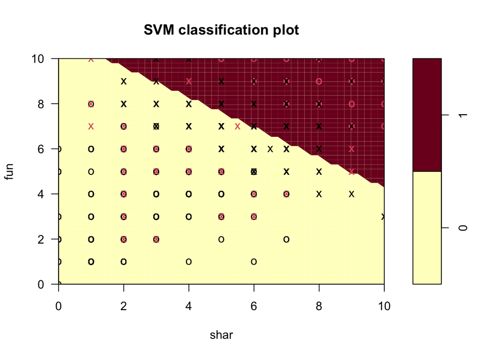

Summary Statistics from Confusion Matrix

| Accuracy | Sensitivity | Specificity |
| --- | --- | --- |
| 0.8088 | 0.8077 | 0.8103 |

Confusion Matrix

|  | False | True |
| --- | --- | --- |
| False | 294 | 48 |
| True | 70 | 205 |

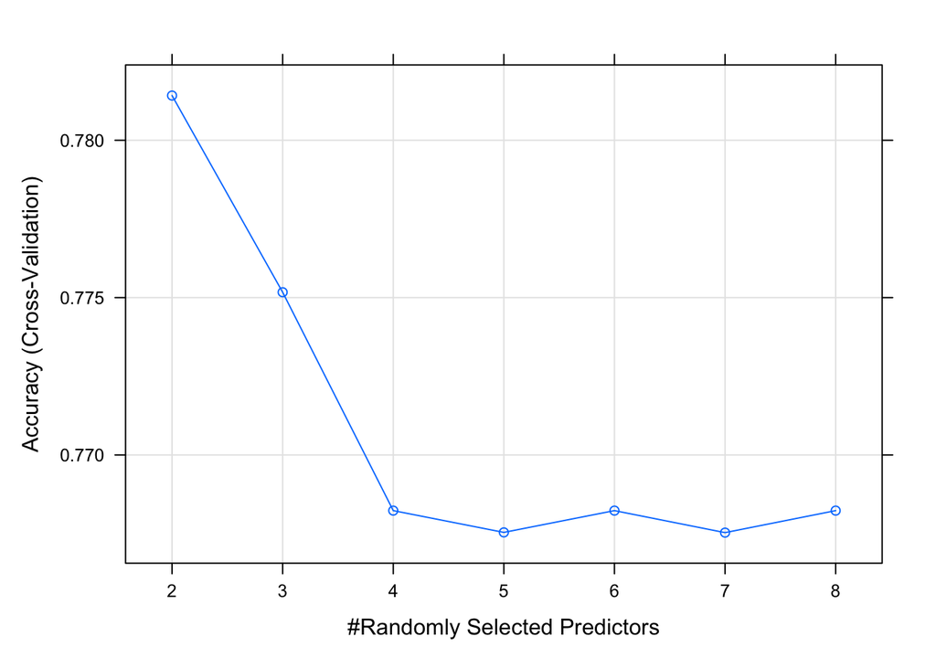

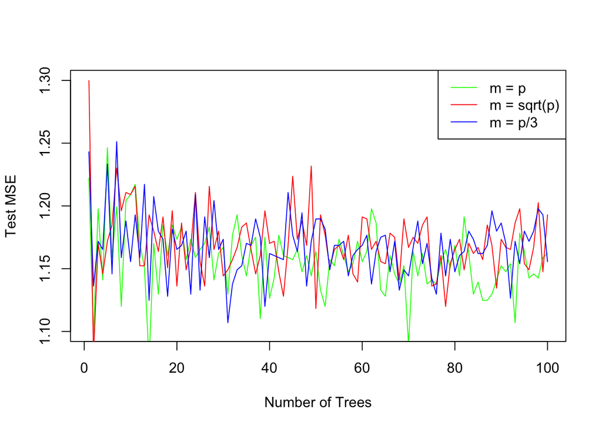

```
## [1] "She is willing to ask for a second date!"
```

### For the second question: “Can we predict the result of matches based on the personal information of participants?”

For analyzing this question, we only pick the personal information that related to the participants themselves for this model. The basic thought for this question is that if the result is good, the personal bias on the match result is significant. Similar to question 1, we also split the dataset but using the 80-20 principle. In other words, 80% of the whole cleaned data is the training set and the other 20% of the whole cleaned data is the testing set. The first model we created is the linear regression model as variables related to the personal background are simple. After the evaluation of the model by examining the mean absolute error, we can see that the MAE of the test data’s residuals is 1.397207, which is relatively small. Therefore, it indicates that the model using the linear regression model is good here. Then we use the decision tree model to explore this question. Using a similar technique to test the model, we can see that the MAE of the test data’s residuals is 1.417723, which is also small enough to indicate a relatively good model. These two models basically solve our question. Since mean absolute errors of test data from both methods are small, we can roughly predict the “like score” just based on the participator’s personal information using linear regression or a decision tree.

[output not shown]

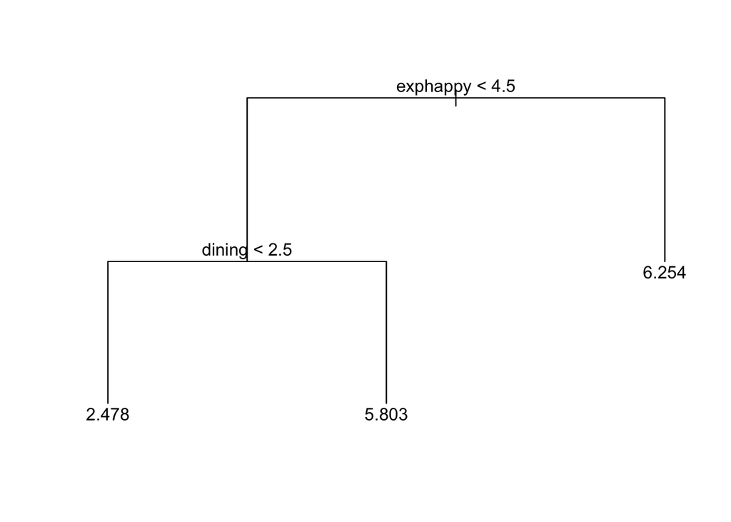

```
## The MAE of residuals using Decision Tree model is 1.417723
```

# CONCLUSION

## For the first question: “Can we predict if a woman will ask for another date with her matched man in Speed Dating Events?”

Overall speaking, when we predict women’s decision of taking another date after the event, LinearSVM and RandomForest really do a great job, meaning that we could predict whether a man will ask for another date with her matched man using some features. However, there is way more than perfect. We did not take the women’s partners’ information into the consideration. We believe the most challenging part is the data cleaning since we need to put their partners’ information into the same sample, which will be a huge process and really complicated. Besides, when the dataset is rebuilt, it will definitely grow larger, meaning more noise will be included in the dataset. At that point, LinearSVM may not be a good model to perform since it will be greatly influenced by outliers. What’s more, though the random forest is a great model to apply, it is so bad at interpretation. Hence, we need to consider other models or a more advanced model like boosting or even a deep learning algorithm like Convolutional Neural Network to make the accuracy better, dealing with the problem we have with the current models. That will be our future goal.

## For the second question: “Can we predict the result of matches based on the personal information of participants?”

For the linear regression model. all features do not have a strong linear relationship with *like_score*, however, the result is not bad if we apply all the features in the model. The *like_score* can be predicted roughly. From the decision tree figure, we can see only *exphappy* and *dining* were actually used in the tree construction. However, the MAE is just 1.42, which looks not bad. This result means 1). the like score can be roughly predicted by personal information, and 2). *exhappy* and *dining* are important characters for checking whether a person would like to give a high *like_score* in our event.